# 统计（机器）学习 Homework-10 报告

林子开 21307110161

2023年12月

# 一、读入数据

```r
soccer <- read_csv("soccer.csv")
```

# 二、绘制相关系数图

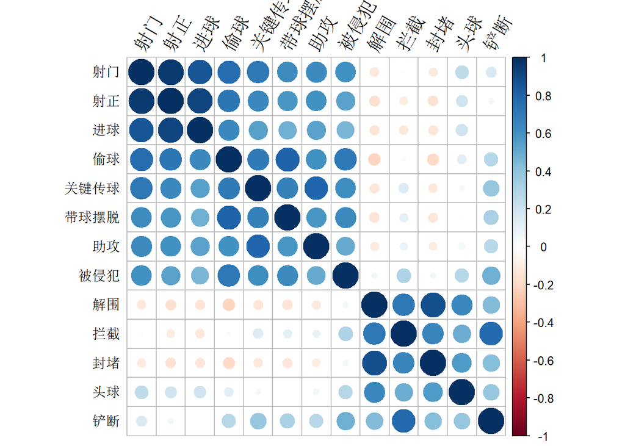

```r
predictor <- soccer[4:16]
M <- cor(predictor)
par(family='STHeiti')
corrplot::corrplot(M, tl.srt = 60,tl.col = "black")
```

# 三、主成分分析

首先，利用**碎石图**确定主成分的个数

```r
par(family='STHeiti')
result1 <- scree(predictor, factors = F, pc = T,
                 main = "主成分分析崖底碎石图")
```

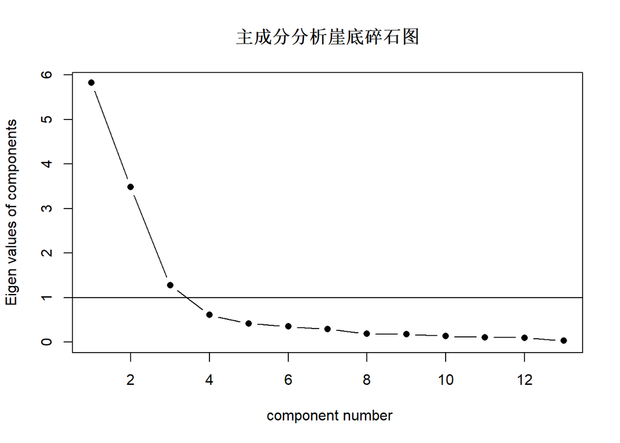

```r
cumvar <- round(cumsum(result1$pcv)/sum(result1$pcv),2)
cat('前三个主成分累计方差贡献率为：', cumvar[1:3]) # 确定主成分个数为3
```

```
## 前三个主成分累计方差贡献率为： 0.45 0.72 0.81
```

根据崖底碎石图的拐点，结合主成分解释总体方差的比例，选择主成分个数为3（前三个主成分累计方差贡献率为81%）。

以下是主成分分析的结果

```r
# 提取主成分
pc <- principal(predictor, nfactors = 3)
pc
```

```
## Principal Components Analysis
## Call: principal(r = predictor, nfactors = 3)
## Standardized loadings (pattern matrix) based upon correlation matrix
##            RC1   RC2   RC3   h2    u2 com
## 射门      0.56  0.00  0.78 0.93 0.071 1.8
## 射正      0.47 -0.06  0.85 0.95 0.052 1.6
## 进球      0.35 -0.05  0.87 0.89 0.114 1.3
## 偷球      0.78 -0.09  0.45 0.82 0.184 1.6
## 关键传球  0.84 -0.04  0.30 0.79 0.207 1.3
## 带球摆脱  0.82 -0.07  0.24 0.74 0.259 1.2
## 助攻      0.73 -0.04  0.33 0.64 0.360 1.4
## 被侵犯    0.76  0.21  0.26 0.69 0.314 1.4
## 解围     -0.14  0.93 -0.05 0.89 0.112 1.0
## 拦截      0.33  0.82 -0.29 0.86 0.137 1.6
## 封堵     -0.12  0.89 -0.05 0.81 0.187 1.0
## 头球     -0.03  0.79  0.38 0.76 0.235 1.4
## 铲断      0.61  0.61 -0.27 0.82 0.176 2.4
##
##                        RC1  RC2  RC3
## SS loadings           4.27 3.40 2.92
## Proportion Var        0.33 0.26 0.22
## Cumulative Var        0.33 0.59 0.81
## Proportion Explained  0.40 0.32 0.28
## Cumulative Proportion 0.40 0.72 1.00
##
## Mean item complexity =  1.5
## Test of the hypothesis that 3 components are sufficient.
##
## The root mean square of the residuals (RMSR) is  0.05
##  with the empirical chi square  496.61  with prob <  5.1e-79
##
## Fit based upon off diagonal values = 0.99
```

下面利用主成分分量的值可以对各个主成分进行解释。**第一主成分**的偷球、关键传球、带球摆脱、助攻、被侵犯分量系数大于0.7，第一主成分可以反映球员在比赛中的配合能力，可以称为**配合因子**。**第二主成分**在解围、拦截、封堵、头球分量上的系数大于0.7，可以反映球员在比赛中的防守能力，可以称为**防守因子**。**第三主成分**在射门、射正、进球分量上的系数大于0.7，可以反映球员在比赛中的进攻的能力，可以称为**进攻因子**。

# 四、计算球员主成分得分

```r
# 计算每一位球员的主成分得分
pc <- principal(predictor, nfactors = 3, scores = TRUE)
```

下面挑选第1位，第16位，第20位球员进行解读。

```r
# 挑选三个球员
player.1 <- pc$scores[1,]
player.16 <- pc$scores[16,]
player.20 <- pc$scores[20,]
```

```r
player.1
```

```
##        RC1        RC2        RC3
## -0.8424595 -0.2233330  0.9279488
```

第一个球员在进攻因子上得分较高，在防守因子上得分较低，说明这个球员的角色可能是前锋，擅长进攻；此外，这个球员在配合因子上得分因子比较低，可能说明这个球员不习惯和队友配合，喜欢单刀，需要增强团队意识.

```r
player.16
```

```
##        RC1        RC2        RC3
## -0.9265605  2.1172595  0.3682909
```

第16个球员，在防守因子上得分较高，在进攻因子上得分较低，说明这位球员的角色可能是后卫。类似的，这位球员在配合因子上得分很低，需要加强团队配合的训练。

```r
player.20
```

```
##         RC1         RC2         RC3
##  3.11875436 -0.99506122 -0.08640582
```

第20个球员，在配合因子上得分非常高，而在进攻因子上得分一般，在防守因子得分上很低。说明这位球员的角色很可能是中锋。这位球员具有非常好的团队配合能力，但也需要提升自己的防守能力，防止己方球队阵型的腰部位置出现空当，被对方突破。

# 五、依据主成分进行K-means聚类

首先，根据碎石图确定最佳聚类个数

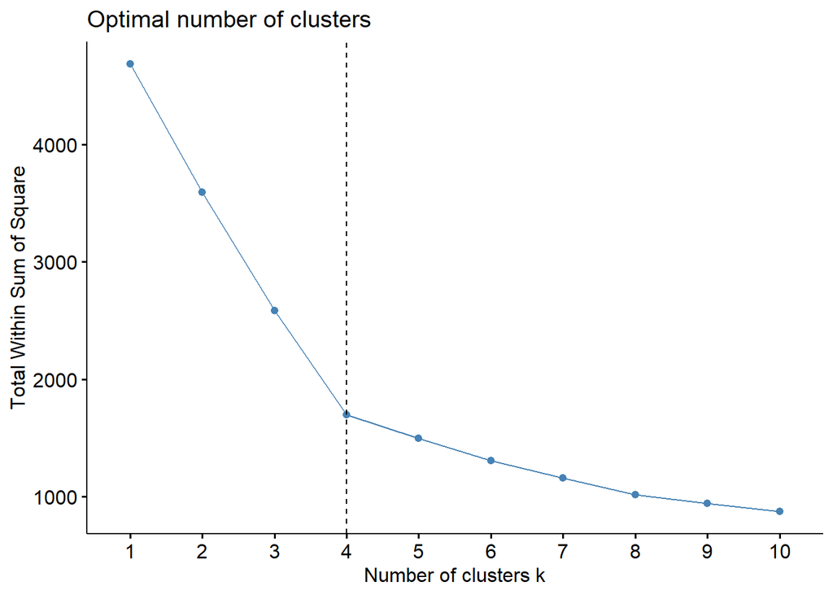

```r
pc.scores <- as.data.frame(pc$scores)
fviz_nbclust(pc.scores, kmeans, method = "wss") + geom_vline(xintercept = 4, linetype = 2)
```

从碎石图可以看出，最佳的聚类个数是4个。

下面按照$k=4$进行k-means聚类，并展示类别人数和聚类中心：

```r
km <- kmeans(pc.scores, 4, nstart = 24)
km$size
```

```
## [1] 387 169 246 761
```

```r
km$centers
```

```
##          RC1        RC2         RC3
## 1  1.2295968  0.1627159 -0.54828241
## 2  0.5044559 -0.2201536  2.26533943
## 3 -0.5927134  1.7289557  0.03649759
## 4 -0.5457287 -0.5927572 -0.23605188
```

**第一个类别**的中心的主成分得分为 (1.2295968, 0.1627159, -0.54828241)，说明这个类别的球员比较善于配合。

**第四个类别**的中心的主成分得分为(-0.5457287, -0.5927572, -0.23605188)， 说明这个类别的球员的水平相对普通，没有突出能力。

下面进行聚类可视化，按照每个球员在防守银子和得分因子（第二个和第三个主成分） 上的得分绘制散点图

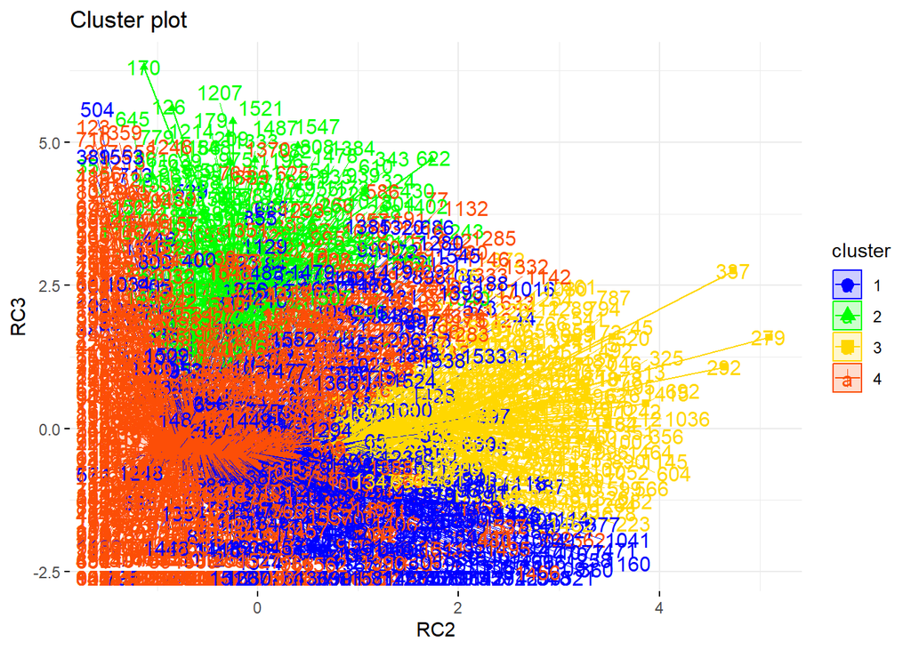

```r
# 聚类可视化
fviz_cluster(km, data = pc.scores[,-1],
             palette = c("blue", "green", "gold", "#FC4E07"),
             ellipse.type = "euclid",
             star.plot = TRUE,
             repel = TRUE,
             ggtheme = theme_minimal()
)
```